# NLP Workshop - Text Mining

Archana Chittoor

November 22, 2019

## Session 2 - NLP Hands-On

In this session, we will start with basic functions in the “dplyr” package which is essential for data wrangling in R. We will proceed to look at some simple plots. Then we will perform some text mining and plot word clouds, followed by sentiment analysis.

```r
install.packages("dplyr",repos = "http://cran.us.r-project.org")
```

#### Dplyr basics

1. Count() function - counts the number of observations of a specific value

```r
library(dplyr)
a <- c(1,2,3,4)
b <- c(2,4,6,8)
levels <- factor(c("A","B","A","B"))
df <- data.frame(first=a,
                 second=b,
                 rank=levels)
df
```

```
##   first second rank
## 1     1      2    A
## 2     2      4    B
## 3     3      6    A
## 4     4      8    B
```

```r
df %>%
  count(rank)
```

```
## # A tibble: 2 x 2
##   rank      n
##   <fct> <int>
## 1 A         2
## 2 B         2
```

```r
df %>%
  count(rank, sort = TRUE)
```

```
## # A tibble: 2 x 2
##   rank      n
##   <fct> <int>
## 1 A         2
## 2 B         2
```

The arrange() function is used to sort columns. By default, it sorts in ascending order. For descending order, we need to specify ‘desc’

```r
df %>%
  arrange(second)
```

```
##   first second rank
## 1     1      2    A
## 2     2      4    B
## 3     3      6    A
## 4     4      8    B
```

```r
df %>%
  arrange(desc(second))
```

```
##   first second rank
## 1     4      8    B
## 2     3      6    A
## 3     2      4    B
## 4     1      2    A
```

The filter() function is used to filter rows in the data

```r
df %>%
  filter(rank == "A")
```

```
##   first second rank
## 1     1      2    A
## 2     3      6    A
```

```r
# This gives only the rows with rank "A"

df %>%
  filter(first == "2")
```

```
##   first second rank
## 1     2      4    B
```

```r
# This gives only the rows with first column as "2"
```

The join() function is used to join two data sets. Inner_join() combines both the data frames and generates a new data frame which has only the rows belonging to the common values of “ID” column

```r
df1 = data.frame(ID = c(1, 2, 3, 4, 5),
                 w = c('a', 'b', 'c', 'd', 'e'),
                 x = c(1, 1, 0, 0, 1),
                 y=rnorm(5),
                 z=letters[1:5])

df1
```

```
##   ID w x          y z
## 1  1 a 1  1.4084373 a
## 2  2 b 1 -0.8617582 b
## 3  3 c 0  0.2149723 c
## 4  4 d 0  1.5813775 d
## 5  5 e 1 -0.2904672 e
```

```r
df2 = data.frame(ID = c(1, 7, 3, 6, 8),
                 a = c('z', 'b', 'k', 'd', 'l'),
                 b = c(1, 2, 3, 0, 4),
                 c =rnorm(5),
                 d =letters[2:6])

df2
```

```
##   ID a b          c d
## 1  1 z 1 -0.1705623 b
## 2  7 b 2  1.3554440 c
## 3  3 k 3 -1.6991495 d
## 4  6 d 0 -0.4145031 e
## 5  8 l 4 -1.6577437 f
```

```r
df3 = inner_join(df1, df2, by = "ID")
df3
```

```
##   ID w x         y z a b          c d
## 1  1 a 1 1.4084373 a z 1 -0.1705623 b
## 2  3 c 0 0.2149723 c k 3 -1.6991495 d
```

The anti_join() function produces as output the data from the first dataframe which is unique to it, it is like the complement of inner_join()

```r
df3 = anti_join(df1, df2, by = "ID")
df3
```

```
##   ID w x          y z
## 1  2 b 1 -0.8617582 b
## 2  4 d 0  1.5813775 d
## 3  5 e 1 -0.2904672 e
```

```r
df3 = anti_join(df2, df1, by = "ID")
df3
```

```
##   ID a b          c d
## 1  7 b 2  1.3554440 c
## 2  6 d 0 -0.4145031 e
## 3  8 l 4 -1.6577437 f
```

### Basic Plotting in R

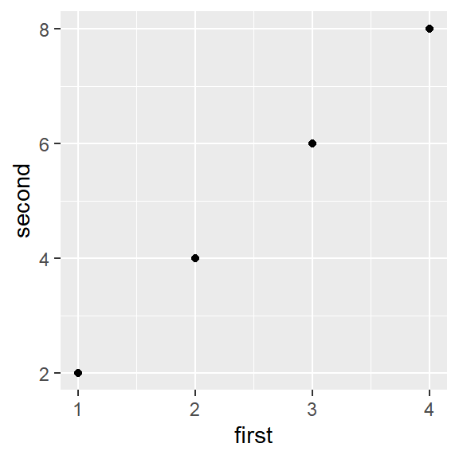

```r
install.packages("ggplot2", repos = "http://cran.us.r-project.org")
library(ggplot2)
df %>%
  ggplot(aes(x = first,y = second)) +
  geom_point()
```

```r
# plot with points
```

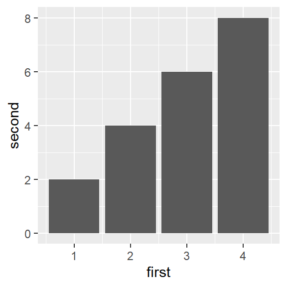

```r
# bar plot with points
df %>%
  ggplot(aes(x = first,y = second)) +
  geom_col()
```

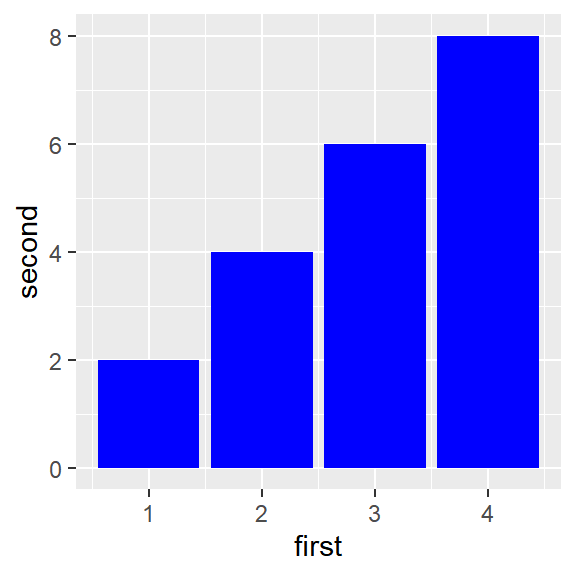

```r
#specifying color
df %>%
  ggplot(aes(x = first,y = second)) +
  geom_col(fill = "blue")
```

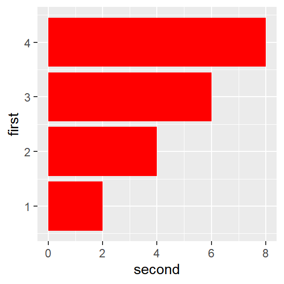

```r
# swapping the coordinates
df %>%
  ggplot(aes(x = first,y = second)) +
  geom_col(fill = "red") +
  coord_flip()
```

Let’s perform Text Analysis on our example, the works of Jane Austen

### Text Analysis process

#### 1. Collecting Raw text

```r
install.packages("janeaustenr", repos = "http://cran.us.r-project.org")
install.packages("stringr", repos = "http://cran.us.r-project.org")
library(janeaustenr)
library(stringr)

original_books <- austen_books()
# text data can be represented as tidy text

# Another way to load the books
#library(gutenbergr)
#austen <- gutenberg_download(c(1342,161,158,121,141))

#library(tm)
# Creating a corpus vector
#a_corpus <- SimpleCorpus(VectorSource(austen$text))

# text data can be converted into a corpus
# cleaning the corpus
#a_corpus <- tm_map(a_corpus, content_transformer(removePunctuation))

#a_corpus <- tm_map(a_corpus, content_transformer(removeNumbers))

#a_corpus  <- tm_map(a_corpus, content_transformer(stemDocument), language = #"english")
```

#### 2.Representing Text

To work with this as a tidy dataset, we need to restructure it in the one-token-per-row format

```r
install.packages("tidytext", repos = "http://cran.us.r-project.org")
#install.packages("dplyr",repos = "http://cran.us.r-project.org")
library(tidytext)
#library(dlpyr)

original_books
```

```
## # A tibble: 73,422 x 2
##    text                  book
##  * <chr>                 <fct>
##  1 SENSE AND SENSIBILITY Sense & Sensibility
##  2 ""                    Sense & Sensibility
##  3 by Jane Austen        Sense & Sensibility
##  4 ""                    Sense & Sensibility
##  5 (1811)                Sense & Sensibility
##  6 ""                    Sense & Sensibility
##  7 ""                    Sense & Sensibility
##  8 ""                    Sense & Sensibility
##  9 ""                    Sense & Sensibility
## 10 CHAPTER 1             Sense & Sensibility
## # ... with 73,412 more rows
```

```r
tidy_books <- original_books %>%
  unnest_tokens(word, text)

# Here input is the text column of original_books and output is stored in the text column of tidy_books
# This function uses the tokenizers package to separate each line of text in the original data frame into tokens.

# Other options are tokenizing into sentences, n-grams, regex etc.

tidy_books_sentences <- original_books %>%
  unnest_tokens(sentence, text,  token = "sentences")

tidy_books_bigram <- original_books %>%
  unnest_tokens(bigram, text, token = "ngrams", n = 2)

tidy_books_chapter <- original_books %>%
  unnest_tokens(chapter, text, token = "regex", pattern = "Chapter [\\d]")

# For our purposes
tidy_books <- original_books %>%
  unnest_tokens(word, text)

tidy_books
```

```
## # A tibble: 725,055 x 2
##    book                word
##    <fct>               <chr>
##  1 Sense & Sensibility sense
##  2 Sense & Sensibility and
##  3 Sense & Sensibility sensibility
##  4 Sense & Sensibility by
##  5 Sense & Sensibility jane
##  6 Sense & Sensibility austen
##  7 Sense & Sensibility 1811
##  8 Sense & Sensibility chapter
##  9 Sense & Sensibility 1
## 10 Sense & Sensibility the
## # ... with 725,045 more rows
```

```r
# remove stop words with an anti_join function.
tidy_books <- tidy_books %>%
  anti_join(stop_words)
tidy_books
```

```
## # A tibble: 217,609 x 2
##    book                word
##    <fct>               <chr>
##  1 Sense & Sensibility sense
##  2 Sense & Sensibility sensibility
##  3 Sense & Sensibility jane
##  4 Sense & Sensibility austen
##  5 Sense & Sensibility 1811
##  6 Sense & Sensibility chapter
##  7 Sense & Sensibility 1
##  8 Sense & Sensibility family
##  9 Sense & Sensibility dashwood
## 10 Sense & Sensibility settled
## # ... with 217,599 more rows
```

#### 3. Analyzing word and document frequency: tf-idf

One measure of how important a word may be is its term frequency (tf) -  
how frequently a word occurs in a document

Another approach is to look at a term’s inverse document frequency (idf), which decreases the weight for commonly used words and increases the weight for words that are not used very much in a collection of documents. This can be combined with term frequency to calculate a term’s tf-idf (the two quantities multiplied together), the frequency of a term adjusted for how rarely it is used. The statistic tf-idf is intended to measure how important a word is to a document in a collection (or corpus) of documents, for example, to one novel in a collection of novels or to one website in a collection of websites.

#### Term frequency in our data (tf)

We can use the already tidied data variable tidy_books

```r
word_count <- tidy_books %>%
  count(word, sort = TRUE)

# counting with book name
book_words <- tidy_books %>%
  count(book, word, sort = TRUE)

book_words
```

```
## # A tibble: 37,224 x 3
##    book                word          n
##    <fct>               <chr>     <int>
##  1 Mansfield Park      fanny       816
##  2 Emma                emma        786
##  3 Sense & Sensibility elinor      623
##  4 Emma                miss        599
##  5 Pride & Prejudice   elizabeth   597
##  6 Mansfield Park      crawford    493
##  7 Sense & Sensibility marianne    492
##  8 Persuasion          anne        447
##  9 Mansfield Park      miss        432
## 10 Northanger Abbey    catherine   428
## # ... with 37,214 more rows
```

#### The bind_tf_idf function:

```r
book_words <- book_words %>%
  bind_tf_idf(word, book, n)

book_words
```

```
## # A tibble: 37,224 x 6
##    book                word          n      tf   idf  tf_idf
##    <fct>               <chr>     <int>   <dbl> <dbl>   <dbl>
##  1 Mansfield Park      fanny       816 0.0170  0.693 0.0118
##  2 Emma                emma        786 0.0168  1.10  0.0185
##  3 Sense & Sensibility elinor      623 0.0171  1.79  0.0307
##  4 Emma                miss        599 0.0128  0     0
##  5 Pride & Prejudice   elizabeth   597 0.0160  0.693 0.0111
##  6 Mansfield Park      crawford    493 0.0103  1.79  0.0184
##  7 Sense & Sensibility marianne    492 0.0135  1.79  0.0243
##  8 Persuasion          anne        447 0.0175  0.182 0.00320
##  9 Mansfield Park      miss        432 0.00901 0     0
## 10 Northanger Abbey    catherine   428 0.0180  0.693 0.0125
## # ... with 37,214 more rows
```

```r
book_words %>%
  arrange(desc(tf_idf))
```

```
## # A tibble: 37,224 x 6
##    book                word          n      tf   idf tf_idf
##    <fct>               <chr>     <int>   <dbl> <dbl>  <dbl>
##  1 Sense & Sensibility elinor      623 0.0171   1.79 0.0307
##  2 Sense & Sensibility marianne    492 0.0135   1.79 0.0243
##  3 Emma                emma        786 0.0168   1.10 0.0185
##  4 Mansfield Park      crawford    493 0.0103   1.79 0.0184
##  5 Pride & Prejudice   darcy       373 0.0100   1.79 0.0179
##  6 Persuasion          elliot      254 0.00997  1.79 0.0179
##  7 Emma                weston      389 0.00832  1.79 0.0149
##  8 Northanger Abbey    tilney      196 0.00823  1.79 0.0148
##  9 Pride & Prejudice   bennet      294 0.00789  1.79 0.0141
## 10 Emma                knightley   356 0.00761  1.79 0.0136
## # ... with 37,214 more rows
```

[figure not shown]

#### 4. Sentiment Analysis

There are a variety of methods and dictionaries that exist for evaluating the opinion or emotion in text. Eg., AFINN, bing, nrc

```r
install.packages("textdata", repos = "http://cran.us.r-project.org")
library(textdata)
get_sentiments("nrc")
```

```
## # A tibble: 13,901 x 2
##    word        sentiment
##    <chr>       <chr>
##  1 abacus      trust
##  2 abandon     fear
##  3 abandon     negative
##  4 abandon     sadness
##  5 abandoned   anger
##  6 abandoned   fear
##  7 abandoned   negative
##  8 abandoned   sadness
##  9 abandonment anger
## 10 abandonment fear
## # ... with 13,891 more rows
```

```r
nrc_joy <- get_sentiments("nrc") %>%
  filter(sentiment == "joy")

emma_words <- tidy_books %>%
  filter(book == "Emma")

emma_words_joy <- emma_words %>%
  inner_join(nrc_joy)
emma_words_joy_count <- emma_words_joy %>%
  count(word, sort = TRUE)

# Or this can be specified in the below manner:

emma_words_joy_count <- tidy_books %>%
filter(book == "Emma") %>%
     inner_join(nrc_joy) %>%
       count(word, sort = TRUE)
bing_word_counts <- tidy_books %>%
  inner_join(get_sentiments("bing")) %>%
  count(word, sentiment, sort = TRUE)
bing_word_counts
```

```
## # A tibble: 2,555 x 3
##    word      sentiment     n
##    <chr>     <chr>     <int>
##  1 miss      negative   1855
##  2 happy     positive    534
##  3 love      positive    495
##  4 pleasure  positive    462
##  5 poor      negative    424
##  6 happiness positive    369
##  7 comfort   positive    292
##  8 doubt     negative    281
##  9 affection positive    272
## 10 perfectly positive    271
## # ... with 2,545 more rows
```

#### Most common positive and negative words

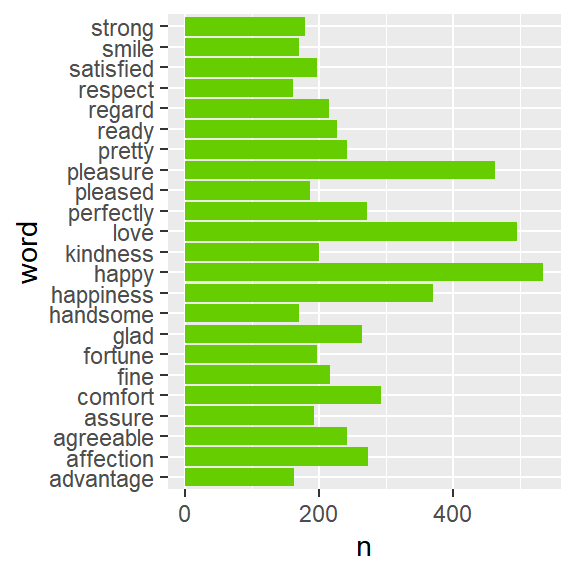

```r
poswords <- filter(bing_word_counts,sentiment == "positive" & n >150)

poswords %>%
  ggplot(aes(word, n)) +
  geom_col(fill = "chartreuse3") +
  coord_flip()
```

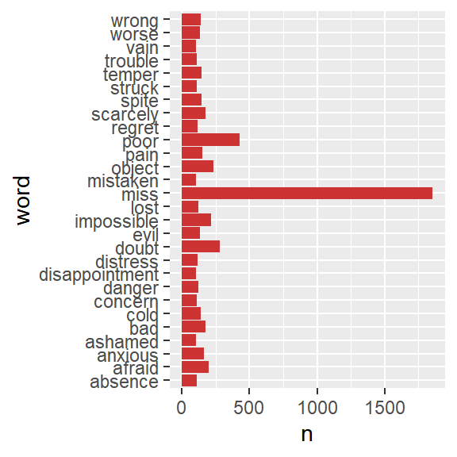

```r
negwords <- filter(bing_word_counts,sentiment == "negative" & n >100)

negwords %>%
  ggplot(aes(word, n)) +
  geom_col(fill = "brown3") +
  coord_flip()
```

#### 5. Gain Insights

##### Word clouds with the most frequent words

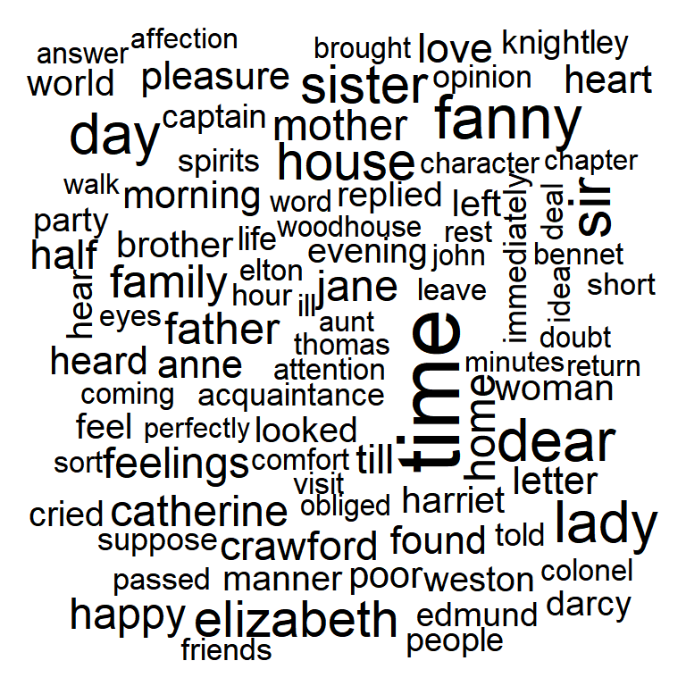

```r
install.packages("wordcloud", repos = "http://cran.us.r-project.org")
install.packages("reshape2", repos = "http://cran.us.r-project.org")
library(wordcloud)
library(reshape2)

word_count %>%
  with(wordcloud(word, n, max.words = 100))
```

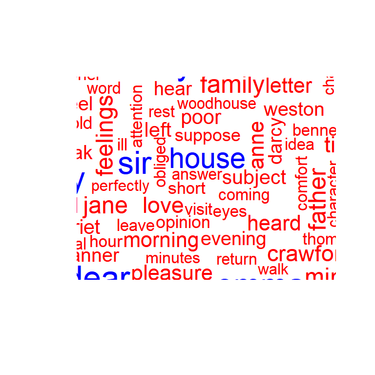

```r
# Specifying colors
word_count %>%
  with(wordcloud(word, n, colors = c("red","blue","green"), max.words = 100))
```

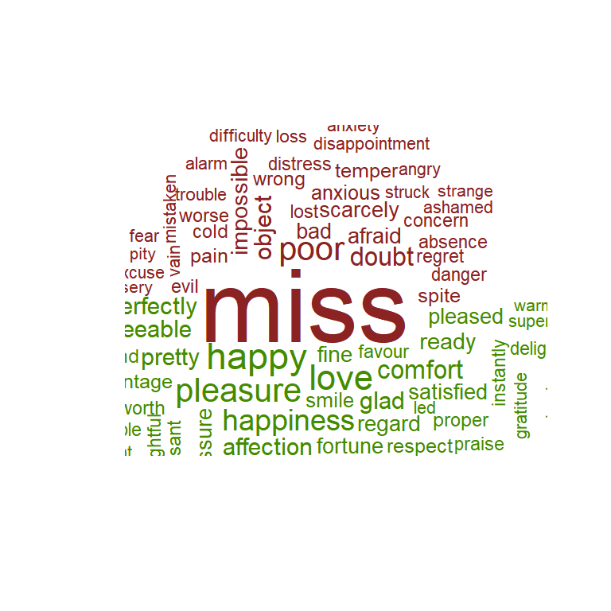

```r
# Plotting a Comparison Cloud

bing_word_counts %>%
  acast(word ~ sentiment, value.var = "n", fill = 0) %>%
  comparison.cloud(colors = c("brown4","chartreuse4"),
                   max.words = 100)
```